# Human Activity Recognition

Matthias Reimann

16 November 2020

# Executive Summary

Using data from accelerometers on the belt, forearm, arm and dumbell of six test persons, a classification prediction of the type of activity is chosen from a set of different methods, including random forest, generalized boosting and classification tree. All methods are tested using the results of a confusion matrix.

# Data Preparation

## Source

All data used in this analysis was retrieved from the following source on 13 November 2020:

Ugulino, W.; Cardador, D.; Vega, K.; Velloso, E.; Milidiu, R.; Fuks, H. Wearable Computing: Accelerometers’ Data Classification of Body Postures and Movements. Proceedings of 21st Brazilian Symposium on Artificial Intelligence. Advances in Artificial Intelligence - SBIA 2012. In: Lecture Notes in Computer Science. , pp. 52-61. Curitiba, PR: Springer Berlin / Heidelberg, 2012. ISBN 978-3-642-34458-9. DOI: 10.1007/978-3-642-34459-6_6.

## Loading

The required data is loaded to tibbles from the CSV files provided by the authors of aforementioned publication.

```r
trainingset <- tibble(read.csv("https://d396qusza40orc.cloudfront.net/predmachlearn/pml-training.csv"))
testset <- tibble(read.csv("https://d396qusza40orc.cloudfront.net/predmachlearn/pml-testing.csv"))
dim(trainingset)
```

```
## [1] 19622   160
```

```r
dim(testset)
```

```
## [1]  20 160
```

## Remove Indexes

All index columens of for which can be assumed from the outset that there is no correlation with the desired classe feature, are excluded

```r
trainingset <- select(trainingset, !X:cvtd_timestamp)
testset <- select(testset, !X:cvtd_timestamp)
```

## Remove Features with many missing Values

Features that contain more than 50% of missing values are dropped from the dataset and will not be included in the analysis.

```r
wdfeatures <- sapply(trainingset, function(x) mean(is.na(x))) > .5
trainingset <- trainingset[, wdfeatures==FALSE]
testset  <- testset[, wdfeatures==FALSE]
dim(trainingset)
```

```
## [1] 19622    88
```

```r
dim(testset)
```

```
## [1] 20 88
```

## Remove Features with little Variance

Features with near zero variance and many missing values are also removed from the dataset, as they contain little or no information useful for prediction.

```r
nzfeatures <- nearZeroVar(trainingset)
trainingset <- trainingset[, -nzfeatures]
testset <- testset[, -nzfeatures]
nzfeatures
```

```
##  [1]  1  7  8  9 10 11 12 13 14 15 38 39 40 41 42 43 47 48 49 50 51 52 53 54 55
## [26] 69 70 71 72 73 74 75 76 77
```

```r
dim(trainingset)
```

```
## [1] 19622    54
```

```r
dim(testset)
```

```
## [1] 20 54
```

# Correlation of independent Features

To gain an overview of existing correlations between independent features, a correlogram can be plotted. It shows few clusters of existing correlations mainly between components of the same feature, so it can be decided to continue with model building an return for an in-depth analysis later as required.

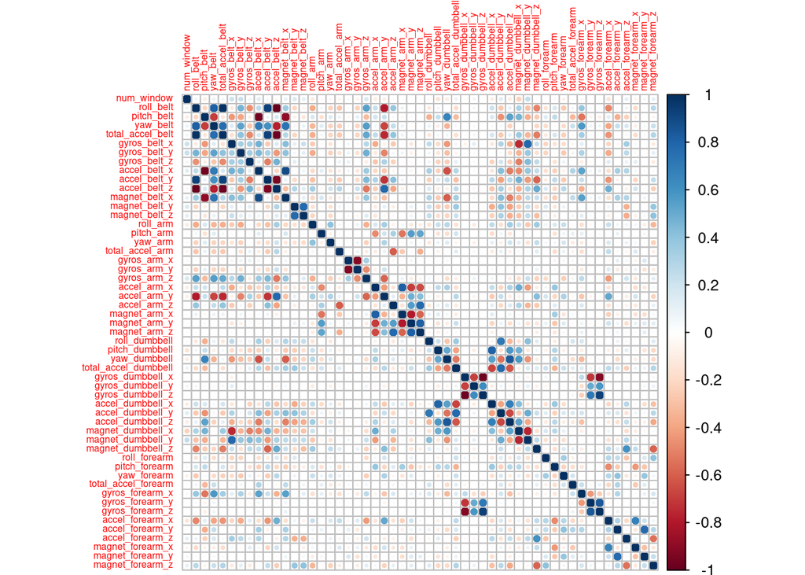

```r
corrplot(cor(select(trainingset, !classe)), method="circle", tl.cex = 0.5)
```

# Models

## Extract Validation Set

The data table is split into a training and a validation set as required by the subsequent training steps. The additional test set will only be used for the following task of the assignment, since it does not contain the required classification information.

```r
tdp  <- createDataPartition(trainingset$classe, p = .7, list = FALSE)
validationset  <- trainingset[-tdp, ]
trainingset <- trainingset[tdp, ]
```

## Random Forest Model

A random forest model is trained using the rf method provided in the caret package.

```r
rfmodel <-
  train(
    classe ~ .,
    data = trainingset,
    method = "rf",
    trControl = trainControl(
      method = "cv",
      number = 5
    ),
    verbose = FALSE
  )

rfmodel$finalModel
```

```
##
## Call:
##  randomForest(x = x, y = y, mtry = param$mtry, verbose = FALSE)
##                Type of random forest: classification
##                      Number of trees: 500
## No. of variables tried at each split: 27
##
##         OOB estimate of  error rate: 0.17%
## Confusion matrix:
##      A    B    C    D    E  class.error
## A 3904    1    0    0    1 0.0005120328
## B    4 2649    4    1    0 0.0033860045
## C    0    4 2392    0    0 0.0016694491
## D    0    0    6 2246    0 0.0026642984
## E    0    0    0    3 2522 0.0011881188
```

```r
rfprediction <- predict(rfmodel, newdata = validationset)
rfconfusion <- confusionMatrix(rfprediction, as.factor(validationset$classe))
rfconfusion
```

```
## Confusion Matrix and Statistics
##
##           Reference
## Prediction    A    B    C    D    E
##          A 1674    0    0    0    0
##          B    0 1139    0    0    0
##          C    0    0 1026    2    0
##          D    0    0    0  962    0
##          E    0    0    0    0 1082
##
## Overall Statistics
##
##                Accuracy : 0.9997
##                  95% CI : (0.9988, 1)
##     No Information Rate : 0.2845
##     P-Value [Acc > NIR] : < 2.2e-16
##
##                   Kappa : 0.9996
##
##  Mcnemar's Test P-Value : NA
##
## Statistics by Class:
##
##                      Class: A Class: B Class: C Class: D Class: E
## Sensitivity            1.0000   1.0000   1.0000   0.9979   1.0000
## Specificity            1.0000   1.0000   0.9996   1.0000   1.0000
## Pos Pred Value         1.0000   1.0000   0.9981   1.0000   1.0000
## Neg Pred Value         1.0000   1.0000   1.0000   0.9996   1.0000
## Prevalence             0.2845   0.1935   0.1743   0.1638   0.1839
## Detection Rate         0.2845   0.1935   0.1743   0.1635   0.1839
## Detection Prevalence   0.2845   0.1935   0.1747   0.1635   0.1839
## Balanced Accuracy      1.0000   1.0000   0.9998   0.9990   1.0000
```

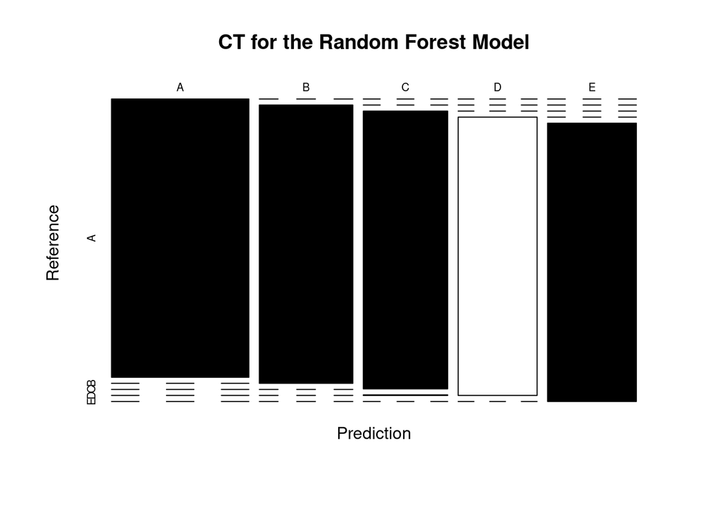

```r
plot(rfconfusion$table, col = rfconfusion$byClass, main = "CT for the Random Forest Model")
```

## Generalized Boosted Model

A generalized boosted model is trained using the gbm method provided in the caret package.

```r
gbmodel <-
  train(
    classe ~ .,
    data = trainingset,
    method = "gbm",
    trControl = trainControl(
      method = "repeatedcv",
      number = 5,
      repeats = 2
    ),
    verbose = FALSE
  )

gbmodel$finalModel
```

```
## A gradient boosted model with multinomial loss function.
## 150 iterations were performed.
## There were 53 predictors of which 53 had non-zero influence.
```

```r
gbprediction <- predict(gbmodel, newdata = validationset)
gbconfusion <- confusionMatrix(gbprediction, as.factor(validationset$classe))
gbconfusion
```

```
## Confusion Matrix and Statistics
##
##           Reference
## Prediction    A    B    C    D    E
##          A 1669    5    0    2    0
##          B    5 1121    7    5    2
##          C    0   11 1015   11    0
##          D    0    2    4  946   11
##          E    0    0    0    0 1069
##
## Overall Statistics
##
##                Accuracy : 0.989
##                  95% CI : (0.9859, 0.9915)
##     No Information Rate : 0.2845
##     P-Value [Acc > NIR] : < 2.2e-16
##
##                   Kappa : 0.986
##
##  Mcnemar's Test P-Value : NA
##
## Statistics by Class:
##
##                      Class: A Class: B Class: C Class: D Class: E
## Sensitivity            0.9970   0.9842   0.9893   0.9813   0.9880
## Specificity            0.9983   0.9960   0.9955   0.9965   1.0000
## Pos Pred Value         0.9958   0.9833   0.9788   0.9823   1.0000
## Neg Pred Value         0.9988   0.9962   0.9977   0.9963   0.9973
## Prevalence             0.2845   0.1935   0.1743   0.1638   0.1839
## Detection Rate         0.2836   0.1905   0.1725   0.1607   0.1816
## Detection Prevalence   0.2848   0.1937   0.1762   0.1636   0.1816
## Balanced Accuracy      0.9977   0.9901   0.9924   0.9889   0.9940
```

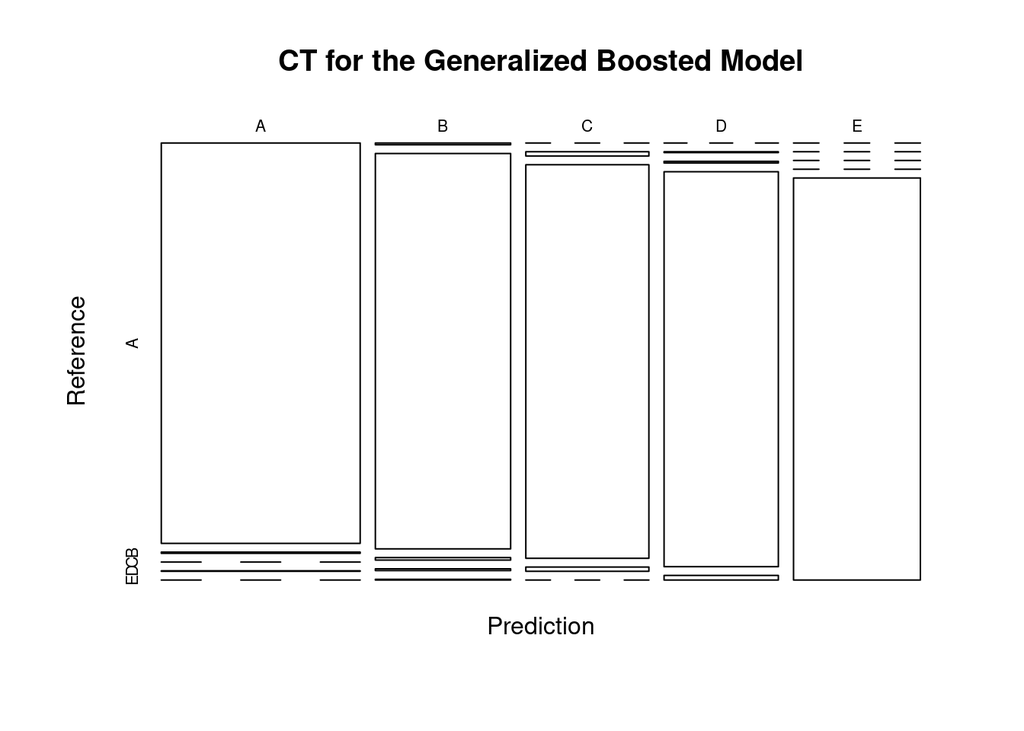

```r
plot(gbconfusion$table, col = gbconfusion$byClass, main = "CT for the Generalized Boosted Model")
```

## Decision Tree Model

```r
dtmodel <-
  train(
    classe ~ .,
    data = trainingset,
    method = "rpart",
    tuneLength = 15
  )

dtmodel
```

```
## CART
##
## 13737 samples
##    53 predictor
##     5 classes: 'A', 'B', 'C', 'D', 'E'
##
## No pre-processing
## Resampling: Bootstrapped (25 reps)
## Summary of sample sizes: 13737, 13737, 13737, 13737, 13737, 13737, ...
## Resampling results across tuning parameters:
##
##   cp          Accuracy   Kappa
##   0.01047706  0.7459999  0.67781807
##   0.01169769  0.7239377  0.65021116
##   0.01179941  0.7222121  0.64808005
##   0.01210457  0.7201453  0.64539901
##   0.01403723  0.7012003  0.62165523
##   0.01668192  0.6867495  0.60347291
##   0.01739396  0.6807184  0.59591687
##   0.01983522  0.6634070  0.57424867
##   0.02156444  0.6488649  0.55586144
##   0.02425999  0.6248065  0.52515317
##   0.03071915  0.5904650  0.48102225
##   0.03407588  0.5645225  0.44755071
##   0.03789035  0.5458455  0.41880664
##   0.06143831  0.4124924  0.20383776
##   0.11565456  0.3220982  0.05929839
##
## Accuracy was used to select the optimal model using the largest value.
## The final value used for the model was cp = 0.01047706.
```

```r
dtprediction <- predict(dtmodel, newdata = validationset)
dtconfusion <- confusionMatrix(dtprediction, as.factor(validationset$classe))
dtconfusion
```

```
## Confusion Matrix and Statistics
##
##           Reference
## Prediction    A    B    C    D    E
##          A 1484  243   40  103   75
##          B   50  636   70   29   95
##          C   17   81  839  156   90
##          D  104  138   51  631  125
##          E   19   41   26   45  697
##
## Overall Statistics
##
##                Accuracy : 0.7285
##                  95% CI : (0.7169, 0.7398)
##     No Information Rate : 0.2845
##     P-Value [Acc > NIR] : < 2.2e-16
##
##                   Kappa : 0.6549
##
##  Mcnemar's Test P-Value : < 2.2e-16
##
## Statistics by Class:
##
##                      Class: A Class: B Class: C Class: D Class: E
## Sensitivity            0.8865   0.5584   0.8177   0.6546   0.6442
## Specificity            0.8905   0.9486   0.9292   0.9151   0.9727
## Pos Pred Value         0.7630   0.7227   0.7092   0.6015   0.8418
## Neg Pred Value         0.9518   0.8995   0.9602   0.9311   0.9239
## Prevalence             0.2845   0.1935   0.1743   0.1638   0.1839
## Detection Rate         0.2522   0.1081   0.1426   0.1072   0.1184
## Detection Prevalence   0.3305   0.1495   0.2010   0.1782   0.1407
## Balanced Accuracy      0.8885   0.7535   0.8735   0.7848   0.8085
```

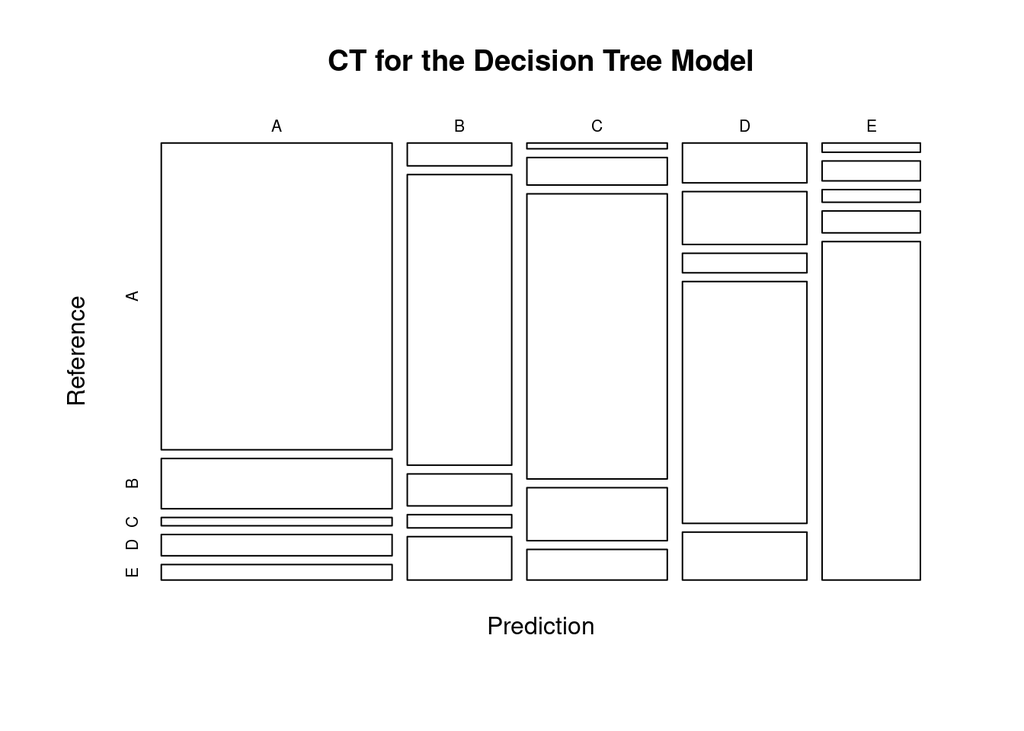

```r
plot(dtconfusion$table, col = dtconfusion$byClass, main = "CT for the Decision Tree Model")
```

# Selection of the best Model

The best model appears to be the random forest with an accuracy exceeding 99%. This model is therefor chosen to make a prediction for the test data as follows.

```r
prediction <- predict(rfmodel, newdata=testset)
prediction
```

```
##  [1] B A B A A E D B A A B C B A E E A B B B
## Levels: A B C D E
```